# Week4 Tutorial - Data Preprocessing

21/2/2021

```r
# Import libraries
library(tidyverse)
library(DataExplorer)
library(VIM)
library(mice)
library(missForest)
# Impute using caret preprocess function
library(caret)
library(psych)
```

## Data set description

#### Reference: https://www.kaggle.com/arashnic/big-mart-sale-forecast

1. BigMart Sale Forecast dataset contains 1559 products across 10 stores in 10 different cities.
2. Each product and store have several pre-defined features. (3)The goal is to build a predictive model to predict the sales of each product in the future. (4)The purpose of this project is that BigMart tries to understand different roles which each product and store play.

## Feature description

### Independent variables

1. Item_Identifier: Product ID.
2. Item_Weight: Weight of products (continuous variable).
3. ItemFatContent: Binary indicator (low fat or not, categorical variable).
4. Item_Visibility: The ratio of the area of displaying a particular product to the total area of a store (in percentage, continuous variable).
5. Item_Type: Category (daily, foods, others, …, categorical variable).
6. Item_MRP: Maximum retail price of the product (continuous variable).
7. Outlet_Identifier: Store ID.
8. OutletEstablishmentYear: The year in which store was established (continuous variable).
9. Outlet_Size: Store’s ground area (categorical variable).
10. Outlet_Location_Type: The type of city in which the store is located (categorical variable).
11. Outlet_Type: Store type (categorical variable).

### Dependent variable

1. ItemOutletSales: Sales of the product in a particular store (continuous variable). The variable to be predicted.

```r
# Load data
df <- read.csv('train.csv', header = T)
df1 <- read.csv('train.csv', header = T)
df2 <- read.csv('train.csv', header = T)
```

## Selected Data Preprocessing Methods

### 1. Missing value treatement

### 2. Data type conversion

### 3. Data Encoding

### 4. Data Normalization

## 1. Missing Value Treatment - Imputation

```r
# We use factors for categorical data. Each label has a unique interger as factor.
# When dataframe is loaded, if the 'factor' variables are read  as 'char', you need to convert them to type "factor" with the following:
df$Item_Fat_Content <- as.factor(df$Item_Fat_Content)
df$Item_Type <- as.factor(df$Item_Type)
df$Outlet_Size <- as.factor(df$Outlet_Size)
df$Outlet_Location_Type <- as.factor(df$Outlet_Location_Type)
df$Outlet_Type <- as.factor(df$Outlet_Type)

# Now we convert 'chr' into 'factor'.
str(df)
```

```
'data.frame':   8522 obs. of  12 variables:
 $ Item_Identifier          : chr  "FDA15" "DRC01" "FDN15" "FDX07" ...
 $ Item_Weight              : num  9.3 5.92 17.5 19.2 8.93 ...
 $ Item_Fat_Content         : Factor w/ 5 levels "LF","low fat",..: 3 5 3 5 3 5 5 3 5 5 ...
 $ Item_Visibility          : num  0.016 0.0193 0.0168 0 0 ...
 $ Item_Type                : Factor w/ 16 levels "Baking Goods",..: 5 15 11 7 10 1 14 14 6 6 ...
 $ Item_MRP                 : num  249.8 48.3 141.6 182.1 53.9 ...
 $ Outlet_Identifier        : chr  "OUT049" "OUT018" "OUT049" "OUT010" ...
 $ Outlet_Establishment_Year: int  1999 2009 1999 1998 1987 2009 1987 1985 2002 2007 ...
 $ Outlet_Size              : Factor w/ 4 levels "","High","Medium",..: 3 3 3 1 2 3 2 3 1 1 ...
 $ Outlet_Location_Type     : Factor w/ 3 levels "Tier 1","Tier 2",..: 1 3 1 3 3 3 3 3 2 2 ...
 $ Outlet_Type              : Factor w/ 4 levels "Grocery Store",..: 2 3 2 1 2 3 2 4 2 2 ...
 $ Item_Outlet_Sales        : num  3735 443 2097 732 995 ...
```

```r
# Prior to treating missing values any blanks in the dataset must be converted to NA
df <- mutate_all(df, na_if, "")
df1 <- mutate_all(df1, na_if, "")
df2 <- mutate_all(df2, na_if, "")
# View (df)
```

```r
# If your dataset has no missing values, introduce missing values to illustrate your abilities in imputation.
# df <- prodNA(ds, noNA = 0.1) # introduces 10% missing values at random
```

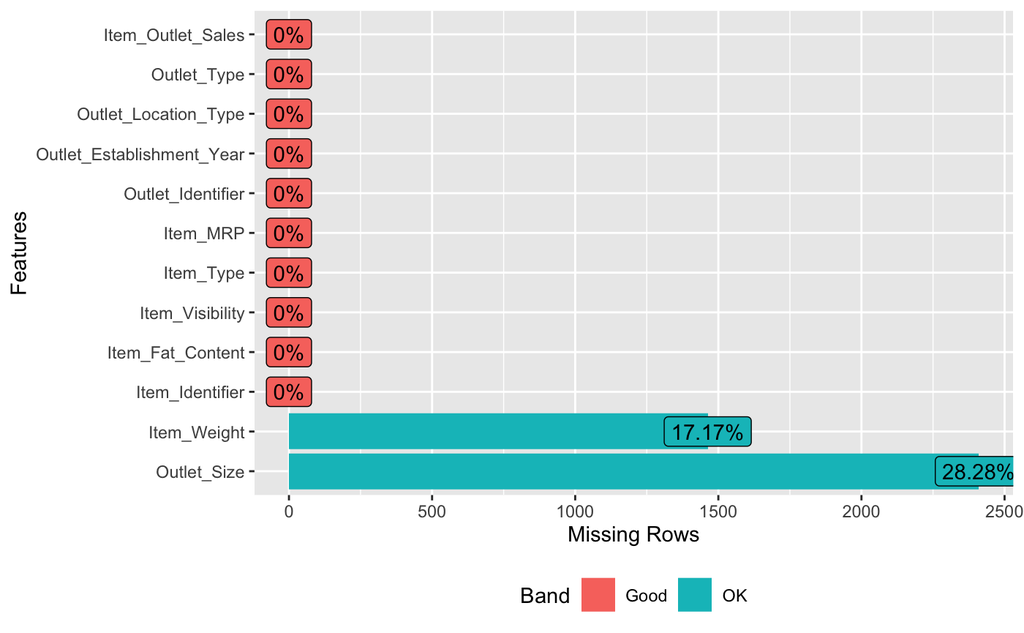

```r
# Viewing and counting missing data
# Uses DataExplorer package
plot_missing(df)
```

We can see that only two features (Item_Weight and Outlet_Size) have missing values. The proportion of missing values for each feature is 17.17% and 28.28%, respectively.

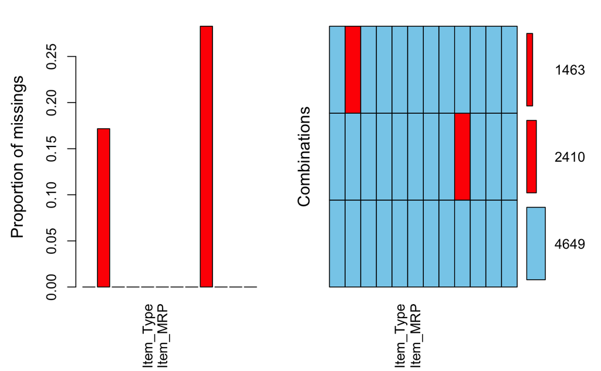

```r
# Needs library(VIM)
vim_plot <- aggr(df, numbers=TRUE, prop = c(TRUE, FALSE))
```

This function plots and calculates the amount of missing values in each variable and in certain combinations. From the left-hand chart, we can see that Item_Weight and Outlet_Size are missing 17% and 28% values, respectively. On the right-hand chart, we can see the missing values’ distribution in a combination. Notice that left-hand chart uses proportions as Y-axis, while the right one uses real number because we set prop = c(TRUE, FALSE).

```
     Item_Identifier Item_Fat_Content Item_Visibility Item_Type Item_MRP Outlet_Identifier
4649               1                1               1         1        1                 1
2410               1                1               1         1        1                 1
1463               1                1               1         1        1                 1
                   0                0               0         0        0                 0
     Outlet_Establishment_Year Outlet_Location_Type Outlet_Type Item_Outlet_Sales Item_Weight
4649                         1                    1           1                 1           1
2410                         1                    1           1                 1           1
1463                         1                    1           1                 1           0
                             0                    0           0                 0        1463
     Outlet_Size
4649           1    0
2410           0    1
1463           1    1
            2410 3873
```

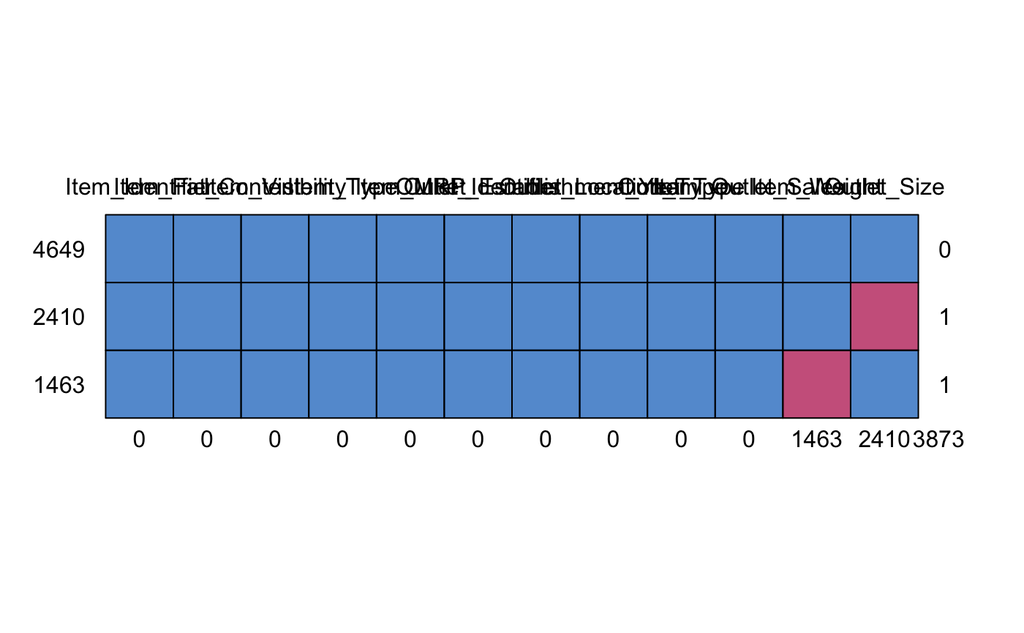

```r
# Uses mice package
md.pattern(df)
```

```r
# Explain the plots using references on mice and VIM (Ref: https://www.datacamp.com/community/tutorials/visualize-data-vim-package)
```

This chart demonstrates the distributon of missing values. The values on the left side represent different groups of the dataset. The values on the right side represent the total number of variables that contain missing value. The top line are names of different variables. The bottom line represents the number of missing values of each variable. From this chart, we can see that there are two variables that have missing values. The number of missing points are 1463 and 2410, respectively. Furthermore, there is no overlap area between two variables’ missing parts.

### 1.1.1 Imputation for continuous variables Method 1

```r
# Reference: https://www.codingprof.com/how-to-replace-nas-with-the-mode-most-frequent-value-in-r/
# Imputing missing values in continuous variables using mean or median.
head(df, 10)
```

|  | Item_Identifier | Item_Weight | Item_Fat_Content | Item_Visibility | Item_Type | Item_MRP | Outlet_Identifier | Outlet_Establishment_Year | Outlet_Size | Outlet_Location_Type | Outlet_Type | Item_Outlet_Sales |
| --- | --- | --- | --- | --- | --- | --- | --- | --- | --- | --- | --- | --- |
| 1 | FDA15 | 9.300 | Low Fat | 0.01604730 | Dairy | 249.8092 | OUT049 | 1999 | Medium | Tier 1 | Supermarket Type1 | 3735.1380 |
| 2 | DRC01 | 5.920 | Regular | 0.01927822 | Soft Drinks | 48.2692 | OUT018 | 2009 | Medium | Tier 3 | Supermarket Type2 | 443.4228 |
| 3 | FDN15 | 17.500 | Low Fat | 0.01676007 | Meat | 141.6180 | OUT049 | 1999 | Medium | Tier 1 | Supermarket Type1 | 2097.2700 |
| 4 | FDX07 | 19.200 | Regular | 0.00000000 | Fruits and Vegetables | 182.0950 | OUT010 | 1998 | NA | Tier 3 | Grocery Store | 732.3800 |
| 5 | NCD19 | 8.930 | Low Fat | 0.00000000 | Household | 53.8614 | OUT013 | 1987 | High | Tier 3 | Supermarket Type1 | 994.7052 |
| 6 | FDP36 | 10.395 | Regular | 0.00000000 | Baking Goods | 51.4008 | OUT018 | 2009 | Medium | Tier 3 | Supermarket Type2 | 556.6088 |
| 7 | FDO10 | 13.650 | Regular | 0.01274109 | Snack Foods | 57.6588 | OUT013 | 1987 | High | Tier 3 | Supermarket Type1 | 343.5528 |
| 8 | FDP10 | NA | Low Fat | 0.12746986 | Snack Foods | 107.7622 | OUT027 | 1985 | Medium | Tier 3 | Supermarket Type3 | 4022.7636 |
| 9 | FDH17 | 16.200 | Regular | 0.01668711 | Frozen Foods | 96.9726 | OUT045 | 2002 | NA | Tier 2 | Supermarket Type1 | 1076.5986 |
| 10 | FDU28 | 19.200 | Regular | 0.09444959 | Frozen Foods | 187.8214 | OUT017 | 2007 | NA | Tier 2 | Supermarket Type1 | 4710.5350 |

```r
df$Item_Weight = ifelse(is.na(df$Item_Weight),
                     ave(df$Item_Weight, FUN = function(x) mean(x, na.rm = TRUE)),
                     df$Item_Weight)
head(df, 10)
```

|  | Item_Identifier | Item_Weight | Item_Fat_Content | Item_Visibility | Item_Type | Item_MRP | Outlet_Identifier | Outlet_Establishment_Year | Outlet_Size | Outlet_Location_Type | Outlet_Type | Item_Outlet_Sales |
| --- | --- | --- | --- | --- | --- | --- | --- | --- | --- | --- | --- | --- |
| 1 | FDA15 | 9.30000 | Low Fat | 0.01604730 | Dairy | 249.8092 | OUT049 | 1999 | Medium | Tier 1 | Supermarket Type1 | 3735.1380 |
| 2 | DRC01 | 5.92000 | Regular | 0.01927822 | Soft Drinks | 48.2692 | OUT018 | 2009 | Medium | Tier 3 | Supermarket Type2 | 443.4228 |
| 3 | FDN15 | 17.50000 | Low Fat | 0.01676007 | Meat | 141.6180 | OUT049 | 1999 | Medium | Tier 1 | Supermarket Type1 | 2097.2700 |
| 4 | FDX07 | 19.20000 | Regular | 0.00000000 | Fruits and Vegetables | 182.0950 | OUT010 | 1998 | NA | Tier 3 | Grocery Store | 732.3800 |
| 5 | NCD19 | 8.93000 | Low Fat | 0.00000000 | Household | 53.8614 | OUT013 | 1987 | High | Tier 3 | Supermarket Type1 | 994.7052 |
| 6 | FDP36 | 10.39500 | Regular | 0.00000000 | Baking Goods | 51.4008 | OUT018 | 2009 | Medium | Tier 3 | Supermarket Type2 | 556.6088 |
| 7 | FDO10 | 13.65000 | Regular | 0.01274109 | Snack Foods | 57.6588 | OUT013 | 1987 | High | Tier 3 | Supermarket Type1 | 343.5528 |
| 8 | FDP10 | 12.85737 | Low Fat | 0.12746986 | Snack Foods | 107.7622 | OUT027 | 1985 | Medium | Tier 3 | Supermarket Type3 | 4022.7636 |
| 9 | FDH17 | 16.20000 | Regular | 0.01668711 | Frozen Foods | 96.9726 | OUT045 | 2002 | NA | Tier 2 | Supermarket Type1 | 1076.5986 |
| 10 | FDU28 | 19.20000 | Regular | 0.09444959 | Frozen Foods | 187.8214 | OUT017 | 2007 | NA | Tier 2 | Supermarket Type1 | 4710.5350 |

```r
# df$Salary = ifelse(is.na(df$Salary),
#                         ave(df$Salary, FUN = function(x) mean(x, na.rm = TRUE)),
#                         df$Salary)
```

### 1.1.2 Imputation for continuous variables Method 2

```r
# Imputing missing values of the continuous variable using median.
# This function only impute continuous variables.
head(df1, 10)
```

|  | Item_Identifier | Item_Weight | Item_Fat_Content | Item_Visibility | Item_Type | Item_MRP | Outlet_Identifier | Outlet_Establishment_Year | Outlet_Size | Outlet_Location_Type | Outlet_Type | Item_Outlet_Sales |
| --- | --- | --- | --- | --- | --- | --- | --- | --- | --- | --- | --- | --- |
| 1 | FDA15 | 9.300 | Low Fat | 0.01604730 | Dairy | 249.8092 | OUT049 | 1999 | Medium | Tier 1 | Supermarket Type1 | 3735.1380 |
| 2 | DRC01 | 5.920 | Regular | 0.01927822 | Soft Drinks | 48.2692 | OUT018 | 2009 | Medium | Tier 3 | Supermarket Type2 | 443.4228 |
| 3 | FDN15 | 17.500 | Low Fat | 0.01676007 | Meat | 141.6180 | OUT049 | 1999 | Medium | Tier 1 | Supermarket Type1 | 2097.2700 |
| 4 | FDX07 | 19.200 | Regular | 0.00000000 | Fruits and Vegetables | 182.0950 | OUT010 | 1998 | NA | Tier 3 | Grocery Store | 732.3800 |
| 5 | NCD19 | 8.930 | Low Fat | 0.00000000 | Household | 53.8614 | OUT013 | 1987 | High | Tier 3 | Supermarket Type1 | 994.7052 |
| 6 | FDP36 | 10.395 | Regular | 0.00000000 | Baking Goods | 51.4008 | OUT018 | 2009 | Medium | Tier 3 | Supermarket Type2 | 556.6088 |
| 7 | FDO10 | 13.650 | Regular | 0.01274109 | Snack Foods | 57.6588 | OUT013 | 1987 | High | Tier 3 | Supermarket Type1 | 343.5528 |
| 8 | FDP10 | NA | Low Fat | 0.12746986 | Snack Foods | 107.7622 | OUT027 | 1985 | Medium | Tier 3 | Supermarket Type3 | 4022.7636 |
| 9 | FDH17 | 16.200 | Regular | 0.01668711 | Frozen Foods | 96.9726 | OUT045 | 2002 | NA | Tier 2 | Supermarket Type1 | 1076.5986 |
| 10 | FDU28 | 19.200 | Regular | 0.09444959 | Frozen Foods | 187.8214 | OUT017 | 2007 | NA | Tier 2 | Supermarket Type1 | 4710.5350 |

```r
preProcValues <- preProcess(df1, method = "medianImpute")
df1 <- predict(preProcValues, df1)
head(df1, 10)
```

|  | Item_Identifier | Item_Weight | Item_Fat_Content | Item_Visibility | Item_Type | Item_MRP | Outlet_Identifier | Outlet_Establishment_Year | Outlet_Size | Outlet_Location_Type | Outlet_Type | Item_Outlet_Sales |
| --- | --- | --- | --- | --- | --- | --- | --- | --- | --- | --- | --- | --- |
| 1 | FDA15 | 9.300 | Low Fat | 0.01604730 | Dairy | 249.8092 | OUT049 | 1999 | Medium | Tier 1 | Supermarket Type1 | 3735.1380 |
| 2 | DRC01 | 5.920 | Regular | 0.01927822 | Soft Drinks | 48.2692 | OUT018 | 2009 | Medium | Tier 3 | Supermarket Type2 | 443.4228 |
| 3 | FDN15 | 17.500 | Low Fat | 0.01676007 | Meat | 141.6180 | OUT049 | 1999 | Medium | Tier 1 | Supermarket Type1 | 2097.2700 |
| 4 | FDX07 | 19.200 | Regular | 0.00000000 | Fruits and Vegetables | 182.0950 | OUT010 | 1998 | NA | Tier 3 | Grocery Store | 732.3800 |
| 5 | NCD19 | 8.930 | Low Fat | 0.00000000 | Household | 53.8614 | OUT013 | 1987 | High | Tier 3 | Supermarket Type1 | 994.7052 |
| 6 | FDP36 | 10.395 | Regular | 0.00000000 | Baking Goods | 51.4008 | OUT018 | 2009 | Medium | Tier 3 | Supermarket Type2 | 556.6088 |
| 7 | FDO10 | 13.650 | Regular | 0.01274109 | Snack Foods | 57.6588 | OUT013 | 1987 | High | Tier 3 | Supermarket Type1 | 343.5528 |
| 8 | FDP10 | 12.600 | Low Fat | 0.12746986 | Snack Foods | 107.7622 | OUT027 | 1985 | Medium | Tier 3 | Supermarket Type3 | 4022.7636 |
| 9 | FDH17 | 16.200 | Regular | 0.01668711 | Frozen Foods | 96.9726 | OUT045 | 2002 | NA | Tier 2 | Supermarket Type1 | 1076.5986 |
| 10 | FDU28 | 19.200 | Regular | 0.09444959 | Frozen Foods | 187.8214 | OUT017 | 2007 | NA | Tier 2 | Supermarket Type1 | 4710.5350 |

### 1.2.1 Imputation for categorical variables Method 1

```r
# How would you complete imputing categorical values in this dataset?
# Imputing missing values in categorical variables using mode.

# 1) Create a function that returns mode of a variable.
fun_mode <- function(x) {
  # List unique variables.
  unique_val <- unique(x)

  # Count occurrence of each variable.
  unique_num <- tabulate(match(x, unique_val))

  # Return the most frequent value.
  unique_val[which.max(unique_num)]
}

# 2) Replace NAs with the most frequent value.
# Specify the name of the column that have NAs. Then, use if_else() to find the missing values. Finally, replace NAs with a pre-defined function.
# We must convert chr to factor for Outlet_Size here, because factor variables are not imputable.
head(df1, 10)
```

|  | Item_Identifier | Item_Weight | Item_Fat_Content | Item_Visibility | Item_Type | Item_MRP | Outlet_Identifier | Outlet_Establishment_Year | Outlet_Size | Outlet_Location_Type | Outlet_Type | Item_Outlet_Sales |
| --- | --- | --- | --- | --- | --- | --- | --- | --- | --- | --- | --- | --- |
| 1 | FDA15 | 9.300 | Low Fat | 0.01604730 | Dairy | 249.8092 | OUT049 | 1999 | Medium | Tier 1 | Supermarket Type1 | 3735.1380 |
| 2 | DRC01 | 5.920 | Regular | 0.01927822 | Soft Drinks | 48.2692 | OUT018 | 2009 | Medium | Tier 3 | Supermarket Type2 | 443.4228 |
| 3 | FDN15 | 17.500 | Low Fat | 0.01676007 | Meat | 141.6180 | OUT049 | 1999 | Medium | Tier 1 | Supermarket Type1 | 2097.2700 |
| 4 | FDX07 | 19.200 | Regular | 0.00000000 | Fruits and Vegetables | 182.0950 | OUT010 | 1998 | NA | Tier 3 | Grocery Store | 732.3800 |
| 5 | NCD19 | 8.930 | Low Fat | 0.00000000 | Household | 53.8614 | OUT013 | 1987 | High | Tier 3 | Supermarket Type1 | 994.7052 |
| 6 | FDP36 | 10.395 | Regular | 0.00000000 | Baking Goods | 51.4008 | OUT018 | 2009 | Medium | Tier 3 | Supermarket Type2 | 556.6088 |
| 7 | FDO10 | 13.650 | Regular | 0.01274109 | Snack Foods | 57.6588 | OUT013 | 1987 | High | Tier 3 | Supermarket Type1 | 343.5528 |
| 8 | FDP10 | 12.600 | Low Fat | 0.12746986 | Snack Foods | 107.7622 | OUT027 | 1985 | Medium | Tier 3 | Supermarket Type3 | 4022.7636 |
| 9 | FDH17 | 16.200 | Regular | 0.01668711 | Frozen Foods | 96.9726 | OUT045 | 2002 | NA | Tier 2 | Supermarket Type1 | 1076.5986 |
| 10 | FDU28 | 19.200 | Regular | 0.09444959 | Frozen Foods | 187.8214 | OUT017 | 2007 | NA | Tier 2 | Supermarket Type1 | 4710.5350 |

```r
df1$Outlet_Size = ifelse(is.na(df1$Outlet_Size),
                     fun_mode(df1$Outlet_Size),
                     df1$Outlet_Size)
head(df1, 10)
```

|  | Item_Identifier | Item_Weight | Item_Fat_Content | Item_Visibility | Item_Type | Item_MRP | Outlet_Identifier | Outlet_Establishment_Year | Outlet_Size | Outlet_Location_Type | Outlet_Type | Item_Outlet_Sales |
| --- | --- | --- | --- | --- | --- | --- | --- | --- | --- | --- | --- | --- |
| 1 | FDA15 | 9.300 | Low Fat | 0.01604730 | Dairy | 249.8092 | OUT049 | 1999 | Medium | Tier 1 | Supermarket Type1 | 3735.1380 |
| 2 | DRC01 | 5.920 | Regular | 0.01927822 | Soft Drinks | 48.2692 | OUT018 | 2009 | Medium | Tier 3 | Supermarket Type2 | 443.4228 |
| 3 | FDN15 | 17.500 | Low Fat | 0.01676007 | Meat | 141.6180 | OUT049 | 1999 | Medium | Tier 1 | Supermarket Type1 | 2097.2700 |
| 4 | FDX07 | 19.200 | Regular | 0.00000000 | Fruits and Vegetables | 182.0950 | OUT010 | 1998 | Medium | Tier 3 | Grocery Store | 732.3800 |
| 5 | NCD19 | 8.930 | Low Fat | 0.00000000 | Household | 53.8614 | OUT013 | 1987 | High | Tier 3 | Supermarket Type1 | 994.7052 |
| 6 | FDP36 | 10.395 | Regular | 0.00000000 | Baking Goods | 51.4008 | OUT018 | 2009 | Medium | Tier 3 | Supermarket Type2 | 556.6088 |
| 7 | FDO10 | 13.650 | Regular | 0.01274109 | Snack Foods | 57.6588 | OUT013 | 1987 | High | Tier 3 | Supermarket Type1 | 343.5528 |
| 8 | FDP10 | 12.600 | Low Fat | 0.12746986 | Snack Foods | 107.7622 | OUT027 | 1985 | Medium | Tier 3 | Supermarket Type3 | 4022.7636 |
| 9 | FDH17 | 16.200 | Regular | 0.01668711 | Frozen Foods | 96.9726 | OUT045 | 2002 | Medium | Tier 2 | Supermarket Type1 | 1076.5986 |
| 10 | FDU28 | 19.200 | Regular | 0.09444959 | Frozen Foods | 187.8214 | OUT017 | 2007 | Medium | Tier 2 | Supermarket Type1 | 4710.5350 |

### 1.2.2 Imputation for categorical variables Method 2

```r
# Create a function for mode
Mode <- function(x) {
      ux <- sort(unique(x))
      ux[which.max(tabulate(match(x, ux)))]
}

head(df, 10)
```

|  | Item_Identifier | Item_Weight | Item_Fat_Content | Item_Visibility | Item_Type | Item_MRP | Outlet_Identifier | Outlet_Establishment_Year | Outlet_Size | Outlet_Location_Type | Outlet_Type | Item_Outlet_Sales |
| --- | --- | --- | --- | --- | --- | --- | --- | --- | --- | --- | --- | --- |
| 1 | FDA15 | 9.30000 | Low Fat | 0.01604730 | Dairy | 249.8092 | OUT049 | 1999 | Medium | Tier 1 | Supermarket Type1 | 3735.1380 |
| 2 | DRC01 | 5.92000 | Regular | 0.01927822 | Soft Drinks | 48.2692 | OUT018 | 2009 | Medium | Tier 3 | Supermarket Type2 | 443.4228 |
| 3 | FDN15 | 17.50000 | Low Fat | 0.01676007 | Meat | 141.6180 | OUT049 | 1999 | Medium | Tier 1 | Supermarket Type1 | 2097.2700 |
| 4 | FDX07 | 19.20000 | Regular | 0.00000000 | Fruits and Vegetables | 182.0950 | OUT010 | 1998 | NA | Tier 3 | Grocery Store | 732.3800 |
| 5 | NCD19 | 8.93000 | Low Fat | 0.00000000 | Household | 53.8614 | OUT013 | 1987 | High | Tier 3 | Supermarket Type1 | 994.7052 |
| 6 | FDP36 | 10.39500 | Regular | 0.00000000 | Baking Goods | 51.4008 | OUT018 | 2009 | Medium | Tier 3 | Supermarket Type2 | 556.6088 |
| 7 | FDO10 | 13.65000 | Regular | 0.01274109 | Snack Foods | 57.6588 | OUT013 | 1987 | High | Tier 3 | Supermarket Type1 | 343.5528 |
| 8 | FDP10 | 12.85737 | Low Fat | 0.12746986 | Snack Foods | 107.7622 | OUT027 | 1985 | Medium | Tier 3 | Supermarket Type3 | 4022.7636 |
| 9 | FDH17 | 16.20000 | Regular | 0.01668711 | Frozen Foods | 96.9726 | OUT045 | 2002 | NA | Tier 2 | Supermarket Type1 | 1076.5986 |
| 10 | FDU28 | 19.20000 | Regular | 0.09444959 | Frozen Foods | 187.8214 | OUT017 | 2007 | NA | Tier 2 | Supermarket Type1 | 4710.5350 |

```r
df["Outlet_Size"] <- lapply(df["Outlet_Size"], function(x)
              replace(x, is.na(x), Mode(x[!is.na(x)])))
head(df, 10)
```

|  | Item_Identifier | Item_Weight | Item_Fat_Content | Item_Visibility | Item_Type | Item_MRP | Outlet_Identifier | Outlet_Establishment_Year | Outlet_Size | Outlet_Location_Type | Outlet_Type | Item_Outlet_Sales |
| --- | --- | --- | --- | --- | --- | --- | --- | --- | --- | --- | --- | --- |
| 1 | FDA15 | 9.30000 | Low Fat | 0.01604730 | Dairy | 249.8092 | OUT049 | 1999 | Medium | Tier 1 | Supermarket Type1 | 3735.1380 |
| 2 | DRC01 | 5.92000 | Regular | 0.01927822 | Soft Drinks | 48.2692 | OUT018 | 2009 | Medium | Tier 3 | Supermarket Type2 | 443.4228 |
| 3 | FDN15 | 17.50000 | Low Fat | 0.01676007 | Meat | 141.6180 | OUT049 | 1999 | Medium | Tier 1 | Supermarket Type1 | 2097.2700 |
| 4 | FDX07 | 19.20000 | Regular | 0.00000000 | Fruits and Vegetables | 182.0950 | OUT010 | 1998 | Medium | Tier 3 | Grocery Store | 732.3800 |
| 5 | NCD19 | 8.93000 | Low Fat | 0.00000000 | Household | 53.8614 | OUT013 | 1987 | High | Tier 3 | Supermarket Type1 | 994.7052 |
| 6 | FDP36 | 10.39500 | Regular | 0.00000000 | Baking Goods | 51.4008 | OUT018 | 2009 | Medium | Tier 3 | Supermarket Type2 | 556.6088 |
| 7 | FDO10 | 13.65000 | Regular | 0.01274109 | Snack Foods | 57.6588 | OUT013 | 1987 | High | Tier 3 | Supermarket Type1 | 343.5528 |
| 8 | FDP10 | 12.85737 | Low Fat | 0.12746986 | Snack Foods | 107.7622 | OUT027 | 1985 | Medium | Tier 3 | Supermarket Type3 | 4022.7636 |
| 9 | FDH17 | 16.20000 | Regular | 0.01668711 | Frozen Foods | 96.9726 | OUT045 | 2002 | Medium | Tier 2 | Supermarket Type1 | 1076.5986 |
| 10 | FDU28 | 19.20000 | Regular | 0.09444959 | Frozen Foods | 187.8214 | OUT017 | 2007 | Medium | Tier 2 | Supermarket Type1 | 4710.5350 |

```r
# Check if there is any NAs
sum(is.na(df))
```

```
[1] 0
```

From the results, we can see that there is no missing values in our dataset, we are ready to go.

```r
# Checking frequencies of factor variables
table (df$Outlet_Size)
```

```
         High Medium  Small
     0    932   5203   2387
```

```r
# identify non numeric columns
i1 <- !sapply(df, is.numeric)
i1
```

```
          Item_Identifier               Item_Weight          Item_Fat_Content
                     TRUE                     FALSE                      TRUE
          Item_Visibility                 Item_Type                  Item_MRP
                    FALSE                      TRUE                     FALSE
        Outlet_Identifier Outlet_Establishment_Year               Outlet_Size
                     TRUE                     FALSE                      TRUE
     Outlet_Location_Type               Outlet_Type         Item_Outlet_Sales
                     TRUE                      TRUE                     FALSE
```

### 1.3 Imputation Method 3 - Mice

```r
# Imputing missing values using mice for continuous variables
# Ref: https://rforpoliticalscience.com/2020/07/28/impute-missing-values-with-mice-package-in-r/
head(df2, 10)
```

|  | Item_Identifier | Item_Weight | Item_Fat_Content | Item_Visibility | Item_Type | Item_MRP | Outlet_Identifier | Outlet_Establishment_Year | Outlet_Size | Outlet_Location_Type | Outlet_Type | Item_Outlet_Sales |
| --- | --- | --- | --- | --- | --- | --- | --- | --- | --- | --- | --- | --- |
| 1 | FDA15 | 9.300 | Low Fat | 0.01604730 | Dairy | 249.8092 | OUT049 | 1999 | Medium | Tier 1 | Supermarket Type1 | 3735.1380 |
| 2 | DRC01 | 5.920 | Regular | 0.01927822 | Soft Drinks | 48.2692 | OUT018 | 2009 | Medium | Tier 3 | Supermarket Type2 | 443.4228 |
| 3 | FDN15 | 17.500 | Low Fat | 0.01676007 | Meat | 141.6180 | OUT049 | 1999 | Medium | Tier 1 | Supermarket Type1 | 2097.2700 |
| 4 | FDX07 | 19.200 | Regular | 0.00000000 | Fruits and Vegetables | 182.0950 | OUT010 | 1998 | NA | Tier 3 | Grocery Store | 732.3800 |
| 5 | NCD19 | 8.930 | Low Fat | 0.00000000 | Household | 53.8614 | OUT013 | 1987 | High | Tier 3 | Supermarket Type1 | 994.7052 |
| 6 | FDP36 | 10.395 | Regular | 0.00000000 | Baking Goods | 51.4008 | OUT018 | 2009 | Medium | Tier 3 | Supermarket Type2 | 556.6088 |
| 7 | FDO10 | 13.650 | Regular | 0.01274109 | Snack Foods | 57.6588 | OUT013 | 1987 | High | Tier 3 | Supermarket Type1 | 343.5528 |
| 8 | FDP10 | NA | Low Fat | 0.12746986 | Snack Foods | 107.7622 | OUT027 | 1985 | Medium | Tier 3 | Supermarket Type3 | 4022.7636 |
| 9 | FDH17 | 16.200 | Regular | 0.01668711 | Frozen Foods | 96.9726 | OUT045 | 2002 | NA | Tier 2 | Supermarket Type1 | 1076.5986 |
| 10 | FDU28 | 19.200 | Regular | 0.09444959 | Frozen Foods | 187.8214 | OUT017 | 2007 | NA | Tier 2 | Supermarket Type1 | 4710.5350 |

```r
imputed_df <- mice(df2, m=3)
df2 <- complete(imputed_df)
head(df2, 10)
```

|  | Item_Identifier | Item_Weight | Item_Fat_Content | Item_Visibility | Item_Type | Item_MRP | Outlet_Identifier | Outlet_Establishment_Year | Outlet_Size | Outlet_Location_Type | Outlet_Type | Item_Outlet_Sales |
| --- | --- | --- | --- | --- | --- | --- | --- | --- | --- | --- | --- | --- |
| 1 | FDA15 | 9.300 | Low Fat | 0.01604730 | Dairy | 249.8092 | OUT049 | 1999 | Medium | Tier 1 | Supermarket Type1 | 3735.1380 |
| 2 | DRC01 | 5.920 | Regular | 0.01927822 | Soft Drinks | 48.2692 | OUT018 | 2009 | Medium | Tier 3 | Supermarket Type2 | 443.4228 |
| 3 | FDN15 | 17.500 | Low Fat | 0.01676007 | Meat | 141.6180 | OUT049 | 1999 | Medium | Tier 1 | Supermarket Type1 | 2097.2700 |
| 4 | FDX07 | 19.200 | Regular | 0.00000000 | Fruits and Vegetables | 182.0950 | OUT010 | 1998 | NA | Tier 3 | Grocery Store | 732.3800 |
| 5 | NCD19 | 8.930 | Low Fat | 0.00000000 | Household | 53.8614 | OUT013 | 1987 | High | Tier 3 | Supermarket Type1 | 994.7052 |
| 6 | FDP36 | 10.395 | Regular | 0.00000000 | Baking Goods | 51.4008 | OUT018 | 2009 | Medium | Tier 3 | Supermarket Type2 | 556.6088 |
| 7 | FDO10 | 13.650 | Regular | 0.01274109 | Snack Foods | 57.6588 | OUT013 | 1987 | High | Tier 3 | Supermarket Type1 | 343.5528 |
| 8 | FDP10 | 10.100 | Low Fat | 0.12746986 | Snack Foods | 107.7622 | OUT027 | 1985 | Medium | Tier 3 | Supermarket Type3 | 4022.7636 |
| 9 | FDH17 | 16.200 | Regular | 0.01668711 | Frozen Foods | 96.9726 | OUT045 | 2002 | NA | Tier 2 | Supermarket Type1 | 1076.5986 |
| 10 | FDU28 | 19.200 | Regular | 0.09444959 | Frozen Foods | 187.8214 | OUT017 | 2007 | NA | Tier 2 | Supermarket Type1 | 4710.5350 |

This function only deal with continuous variables, leaving categorical variables as NAs still.

### 1.4 Imputation Method 4 - missForest

```r
# # Imputing missing values using missForest
# index <- c(2, 3)
# dr <- missForest(df2[2, 3], verbose = TRUE) # Is dr a dataframe?
# dq<- dr$ximp # What is dq?
# # View dq and comment
# # If there are any floating values where you expect an integer, round it to integer
# # you may use: dataset$col <- round (dataset$col)
# # Once again View the data and comment
# View(dr)
# View(dq)
```

## 2. Data type Conversion

```r
# where necessary use the following:
# df$col <- as.factor (df$col)
# df$col <- as.numeric (df$col)
# df$col <- as.character (df$col)
```

## 3. Data Encoding

### 3.1 Data Encoding - Converting to numeric - Ordinal/Nominal variables

```r
head(df1)
```

|  | Item_Identifier | Item_Weight | Item_Fat_Content | Item_Visibility | Item_Type | Item_MRP | Outlet_Identifier | Outlet_Establishment_Year | Outlet_Size | Outlet_Location_Type | Outlet_Type | Item_Outlet_Sales |
| --- | --- | --- | --- | --- | --- | --- | --- | --- | --- | --- | --- | --- |
| 1 | FDA15 | 9.300 | Low Fat | 0.01604730 | Dairy | 249.8092 | OUT049 | 1999 | Medium | Tier 1 | Supermarket Type1 | 3735.1380 |
| 2 | DRC01 | 5.920 | Regular | 0.01927822 | Soft Drinks | 48.2692 | OUT018 | 2009 | Medium | Tier 3 | Supermarket Type2 | 443.4228 |
| 3 | FDN15 | 17.500 | Low Fat | 0.01676007 | Meat | 141.6180 | OUT049 | 1999 | Medium | Tier 1 | Supermarket Type1 | 2097.2700 |
| 4 | FDX07 | 19.200 | Regular | 0.00000000 | Fruits and Vegetables | 182.0950 | OUT010 | 1998 | Medium | Tier 3 | Grocery Store | 732.3800 |
| 5 | NCD19 | 8.930 | Low Fat | 0.00000000 | Household | 53.8614 | OUT013 | 1987 | High | Tier 3 | Supermarket Type1 | 994.7052 |
| 6 | FDP36 | 10.395 | Regular | 0.00000000 | Baking Goods | 51.4008 | OUT018 | 2009 | Medium | Tier 3 | Supermarket Type2 | 556.6088 |

```r
df1$Outlet_Size <- factor(df1$Outlet_Size,
                          levels = c('High', 'Medium', 'SmallFrance'),
                          labels = c(1, 2, 3))
head(df1)
```

|  | Item_Identifier | Item_Weight | Item_Fat_Content | Item_Visibility | Item_Type | Item_MRP | Outlet_Identifier | Outlet_Establishment_Year | Outlet_Size | Outlet_Location_Type | Outlet_Type | Item_Outlet_Sales |
| --- | --- | --- | --- | --- | --- | --- | --- | --- | --- | --- | --- | --- |
| 1 | FDA15 | 9.300 | Low Fat | 0.01604730 | Dairy | 249.8092 | OUT049 | 1999 | 2 | Tier 1 | Supermarket Type1 | 3735.1380 |
| 2 | DRC01 | 5.920 | Regular | 0.01927822 | Soft Drinks | 48.2692 | OUT018 | 2009 | 2 | Tier 3 | Supermarket Type2 | 443.4228 |
| 3 | FDN15 | 17.500 | Low Fat | 0.01676007 | Meat | 141.6180 | OUT049 | 1999 | 2 | Tier 1 | Supermarket Type1 | 2097.2700 |
| 4 | FDX07 | 19.200 | Regular | 0.00000000 | Fruits and Vegetables | 182.0950 | OUT010 | 1998 | 2 | Tier 3 | Grocery Store | 732.3800 |
| 5 | NCD19 | 8.930 | Low Fat | 0.00000000 | Household | 53.8614 | OUT013 | 1987 | 1 | Tier 3 | Supermarket Type1 | 994.7052 |
| 6 | FDP36 | 10.395 | Regular | 0.00000000 | Baking Goods | 51.4008 | OUT018 | 2009 | 2 | Tier 3 | Supermarket Type2 | 556.6088 |

```r
# This code is for strings
head(df1)
```

|  | Item_Identifier | Item_Weight | Item_Fat_Content | Item_Visibility | Item_Type | Item_MRP | Outlet_Identifier | Outlet_Establishment_Year | Outlet_Size | Outlet_Location_Type | Outlet_Type | Item_Outlet_Sales |
| --- | --- | --- | --- | --- | --- | --- | --- | --- | --- | --- | --- | --- |
| 1 | FDA15 | 9.300 | Low Fat | 0.01604730 | Dairy | 249.8092 | OUT049 | 1999 | 2 | Tier 1 | Supermarket Type1 | 3735.1380 |
| 2 | DRC01 | 5.920 | Regular | 0.01927822 | Soft Drinks | 48.2692 | OUT018 | 2009 | 2 | Tier 3 | Supermarket Type2 | 443.4228 |
| 3 | FDN15 | 17.500 | Low Fat | 0.01676007 | Meat | 141.6180 | OUT049 | 1999 | 2 | Tier 1 | Supermarket Type1 | 2097.2700 |
| 4 | FDX07 | 19.200 | Regular | 0.00000000 | Fruits and Vegetables | 182.0950 | OUT010 | 1998 | 2 | Tier 3 | Grocery Store | 732.3800 |
| 5 | NCD19 | 8.930 | Low Fat | 0.00000000 | Household | 53.8614 | OUT013 | 1987 | 1 | Tier 3 | Supermarket Type1 | 994.7052 |
| 6 | FDP36 | 10.395 | Regular | 0.00000000 | Baking Goods | 51.4008 | OUT018 | 2009 | 2 | Tier 3 | Supermarket Type2 | 556.6088 |

```r
df1 <- df1 %>% mutate(Item_Fat_Content =
                     case_when(Item_Fat_Content == "LF" ~ "1",
                               Item_Fat_Content == "low fat" ~ "2",
                               Item_Fat_Content == "Low Fat" ~ "3",
                               Item_Fat_Content == "reg" ~ "4",
                               Item_Fat_Content == "Regular" ~ "5"))

df1$Item_Fat_Content <- as.numeric(df1$Item_Fat_Content)
head(df1)
```

|  | Item_Identifier | Item_Weight | Item_Fat_Content | Item_Visibility | Item_Type | Item_MRP | Outlet_Identifier | Outlet_Establishment_Year | Outlet_Size | Outlet_Location_Type | Outlet_Type | Item_Outlet_Sales |
| --- | --- | --- | --- | --- | --- | --- | --- | --- | --- | --- | --- | --- |
| 1 | FDA15 | 9.300 | 3 | 0.01604730 | Dairy | 249.8092 | OUT049 | 1999 | 2 | Tier 1 | Supermarket Type1 | 3735.1380 |
| 2 | DRC01 | 5.920 | 5 | 0.01927822 | Soft Drinks | 48.2692 | OUT018 | 2009 | 2 | Tier 3 | Supermarket Type2 | 443.4228 |
| 3 | FDN15 | 17.500 | 3 | 0.01676007 | Meat | 141.6180 | OUT049 | 1999 | 2 | Tier 1 | Supermarket Type1 | 2097.2700 |
| 4 | FDX07 | 19.200 | 5 | 0.00000000 | Fruits and Vegetables | 182.0950 | OUT010 | 1998 | 2 | Tier 3 | Grocery Store | 732.3800 |
| 5 | NCD19 | 8.930 | 3 | 0.00000000 | Household | 53.8614 | OUT013 | 1987 | 1 | Tier 3 | Supermarket Type1 | 994.7052 |
| 6 | FDP36 | 10.395 | 5 | 0.00000000 | Baking Goods | 51.4008 | OUT018 | 2009 | 2 | Tier 3 | Supermarket Type2 | 556.6088 |

### 3.2 Onehot Encoding - Nominal variables

#### 3.2.1 Method 1 - Direct conversion from label to oneHot

```r
# Ref: https://cran.r-project.org/web/packages/DataExplorer/vignettes/dataexplorer-intro.html#correlation-analysis
head(df)
```

|  | Item_Identifier | Item_Weight | Item_Fat_Content | Item_Visibility | Item_Type | Item_MRP | Outlet_Identifier | Outlet_Establishment_Year | Outlet_Size | Outlet_Location_Type | Outlet_Type | Item_Outlet_Sales |
| --- | --- | --- | --- | --- | --- | --- | --- | --- | --- | --- | --- | --- |
| 1 | FDA15 | 9.300 | Low Fat | 0.01604730 | Dairy | 249.8092 | OUT049 | 1999 | Medium | Tier 1 | Supermarket Type1 | 3735.1380 |
| 2 | DRC01 | 5.920 | Regular | 0.01927822 | Soft Drinks | 48.2692 | OUT018 | 2009 | Medium | Tier 3 | Supermarket Type2 | 443.4228 |
| 3 | FDN15 | 17.500 | Low Fat | 0.01676007 | Meat | 141.6180 | OUT049 | 1999 | Medium | Tier 1 | Supermarket Type1 | 2097.2700 |
| 4 | FDX07 | 19.200 | Regular | 0.00000000 | Fruits and Vegetables | 182.0950 | OUT010 | 1998 | Medium | Tier 3 | Grocery Store | 732.3800 |
| 5 | NCD19 | 8.930 | Low Fat | 0.00000000 | Household | 53.8614 | OUT013 | 1987 | High | Tier 3 | Supermarket Type1 | 994.7052 |
| 6 | FDP36 | 10.395 | Regular | 0.00000000 | Baking Goods | 51.4008 | OUT018 | 2009 | Medium | Tier 3 | Supermarket Type2 | 556.6088 |

```r
df = df %>% mutate(value = 1)  %>% spread(Item_Fat_Content, value,  fill = 0)
df = df %>% mutate(value = 1)  %>% spread(Item_Type, value,  fill = 0)
df = df %>% mutate(value = 1)  %>% spread(Outlet_Size, value,  fill = 0)
df = df %>% mutate(value = 1)  %>% spread(Outlet_Location_Type, value,  fill = 0)
df = df %>% mutate(value = 1)  %>% spread(Outlet_Type, value,  fill = 0)
head(df)
```

|  | Item_Identifier | Item_Weight | Item_Visibility | Item_MRP | Outlet_Identifier | Outlet_Establishment_Year | Item_Outlet_Sales | LF | low fat | Low Fat | reg | Regular | Baking Goods | Breads | Breakfast | Canned | Dairy | Frozen Foods | Fruits and Vegetables | Hard Drinks | Health and Hygiene | Household | Meat | Others | Seafood | Snack Foods | Soft Drinks | Starchy Foods | High | … |
| --- | --- | --- | --- | --- | --- | --- | --- | --- | --- | --- | --- | --- | --- | --- | --- | --- | --- | --- | --- | --- | --- | --- | --- | --- | --- | --- | --- | --- | --- | --- |
| 1 | FDA15 | 9.300 | 0.01604730 | 249.8092 | OUT049 | 1999 | 3735.1380 | 0 | 0 | 1 | 0 | 0 | 0 | 0 | 0 | 0 | 1 | 0 | 0 | 0 | 0 | 0 | 0 | 0 | 0 | 0 | 0 | 0 | 0 | … |
| 2 | DRC01 | 5.920 | 0.01927822 | 48.2692 | OUT018 | 2009 | 443.4228 | 0 | 0 | 0 | 0 | 1 | 0 | 0 | 0 | 0 | 0 | 0 | 0 | 0 | 0 | 0 | 0 | 0 | 0 | 0 | 1 | 0 | 0 | … |
| 3 | FDN15 | 17.500 | 0.01676007 | 141.6180 | OUT049 | 1999 | 2097.2700 | 0 | 0 | 1 | 0 | 0 | 0 | 0 | 0 | 0 | 0 | 0 | 0 | 0 | 0 | 0 | 1 | 0 | 0 | 0 | 0 | 0 | 0 | … |
| 4 | FDX07 | 19.200 | 0.00000000 | 182.0950 | OUT010 | 1998 | 732.3800 | 0 | 0 | 0 | 0 | 1 | 0 | 0 | 0 | 0 | 0 | 0 | 1 | 0 | 0 | 0 | 0 | 0 | 0 | 0 | 0 | 0 | 0 | … |
| 5 | NCD19 | 8.930 | 0.00000000 | 53.8614 | OUT013 | 1987 | 994.7052 | 0 | 0 | 1 | 0 | 0 | 0 | 0 | 0 | 0 | 0 | 0 | 0 | 0 | 0 | 1 | 0 | 0 | 0 | 0 | 0 | 0 | 1 | … |
| 6 | FDP36 | 10.395 | 0.00000000 | 51.4008 | OUT018 | 2009 | 556.6088 | 0 | 0 | 0 | 0 | 1 | 1 | 0 | 0 | 0 | 0 | 0 | 0 | 0 | 0 | 0 | 0 | 0 | 0 | 0 | 0 | 0 | 0 | … |

```r
# dataset_dummified <- dummify(df_test, maxcat = 12L)
# View(dataset_dummified)
```

#### 3.2.2 Method 2 - Direct conversion from label to oneHot

```r
# # Given below are only sample codes.
# # You need to change the datset reference in the following code to match with dataframes used earlier in this document
#
# dmy <- dummyVars(" ~ .", data = df)
# dataset_onehot <- data.frame(predict(dmy, newdata = df))
# dataset_onehot
```

## 4. Data Normalization - suitable for continuous variables

### 4.1 Min-max normalization

```r
# df$Salary <- (df$Salary - min(df$Salary))/(max(df$Salary) - min(df$Salary))
```

```r
# df$Salary <- round(df$Salary, digits = 3)
```

### Task - Write a code to perform min-max normalization on all the continuous variables in the datset

```r
summary(df)
```

```
 Item_Identifier     Item_Weight     Item_Visibility      Item_MRP      Outlet_Identifier
 Length:8522        Min.   : 4.555   Min.   :0.00000   Min.   : 31.29   Length:8522
 Class :character   1st Qu.: 9.310   1st Qu.:0.02699   1st Qu.: 93.84   Class :character
 Mode  :character   Median :12.857   Median :0.05394   Median :143.01   Mode  :character
                    Mean   :12.857   Mean   :0.06613   Mean   :141.00
                    3rd Qu.:16.000   3rd Qu.:0.09459   3rd Qu.:185.65
                    Max.   :21.350   Max.   :0.32839   Max.   :266.89
 Outlet_Establishment_Year Item_Outlet_Sales        LF             low fat           Low Fat
 Min.   :1985              Min.   :   33.29   Min.   :0.00000   Min.   :0.00000   Min.   :0.000
 1st Qu.:1987              1st Qu.:  834.91   1st Qu.:0.00000   1st Qu.:0.00000   1st Qu.:0.000
 Median :1999              Median : 1794.33   Median :0.00000   Median :0.00000   Median :1.000
 Mean   :1998              Mean   : 2181.45   Mean   :0.03708   Mean   :0.01314   Mean   :0.597
 3rd Qu.:2004              3rd Qu.: 3101.30   3rd Qu.:0.00000   3rd Qu.:0.00000   3rd Qu.:1.000
 Max.   :2009              Max.   :13086.97   Max.   :1.00000   Max.   :1.00000   Max.   :1.000
      reg             Regular       Baking Goods         Breads          Breakfast
 Min.   :0.00000   Min.   :0.000   Min.   :0.00000   Min.   :0.00000   Min.   :0.00000
 1st Qu.:0.00000   1st Qu.:0.000   1st Qu.:0.00000   1st Qu.:0.00000   1st Qu.:0.00000
 Median :0.00000   Median :0.000   Median :0.00000   Median :0.00000   Median :0.00000
 Mean   :0.01373   Mean   :0.339   Mean   :0.07604   Mean   :0.02945   Mean   :0.01291
 3rd Qu.:0.00000   3rd Qu.:1.000   3rd Qu.:0.00000   3rd Qu.:0.00000   3rd Qu.:0.00000
 Max.   :1.00000   Max.   :1.000   Max.   :1.00000   Max.   :1.00000   Max.   :1.00000
     Canned            Dairy          Frozen Foods    Fruits and Vegetables  Hard Drinks
 Min.   :0.00000   Min.   :0.00000   Min.   :0.0000   Min.   :0.0000        Min.   :0.00000
 1st Qu.:0.00000   1st Qu.:0.00000   1st Qu.:0.0000   1st Qu.:0.0000        1st Qu.:0.00000
 Median :0.00000   Median :0.00000   Median :0.0000   Median :0.0000        Median :0.00000
 Mean   :0.07616   Mean   :0.08003   Mean   :0.1004   Mean   :0.1446        Mean   :0.02511
 3rd Qu.:0.00000   3rd Qu.:0.00000   3rd Qu.:0.0000   3rd Qu.:0.0000        3rd Qu.:0.00000
 Max.   :1.00000   Max.   :1.00000   Max.   :1.0000   Max.   :1.0000        Max.   :1.00000
 Health and Hygiene   Household           Meat             Others           Seafood
 Min.   :0.00000    Min.   :0.0000   Min.   :0.00000   Min.   :0.00000   Min.   :0.00000
 1st Qu.:0.00000    1st Qu.:0.0000   1st Qu.:0.00000   1st Qu.:0.00000   1st Qu.:0.00000
 Median :0.00000    Median :0.0000   Median :0.00000   Median :0.00000   Median :0.00000
 Mean   :0.06102    Mean   :0.1068   Mean   :0.04987   Mean   :0.01983   Mean   :0.00751
 3rd Qu.:0.00000    3rd Qu.:0.0000   3rd Qu.:0.00000   3rd Qu.:0.00000   3rd Qu.:0.00000
 Max.   :1.00000    Max.   :1.0000   Max.   :1.00000   Max.   :1.00000   Max.   :1.00000
  Snack Foods      Soft Drinks     Starchy Foods          High            Medium
 Min.   :0.0000   Min.   :0.0000   Min.   :0.00000   Min.   :0.0000   Min.   :0.0000
 1st Qu.:0.0000   1st Qu.:0.0000   1st Qu.:0.00000   1st Qu.:0.0000   1st Qu.:0.0000
 Median :0.0000   Median :0.0000   Median :0.00000   Median :0.0000   Median :1.0000
 Mean   :0.1408   Mean   :0.0521   Mean   :0.01737   Mean   :0.1094   Mean   :0.6105
 3rd Qu.:0.0000   3rd Qu.:0.0000   3rd Qu.:0.00000   3rd Qu.:0.0000   3rd Qu.:1.0000
 Max.   :1.0000   Max.   :1.0000   Max.   :1.00000   Max.   :1.0000   Max.   :1.0000
     Small            Tier 1           Tier 2           Tier 3       Grocery Store
 Min.   :0.0000   Min.   :0.0000   Min.   :0.0000   Min.   :0.0000   Min.   :0.0000
 1st Qu.:0.0000   1st Qu.:0.0000   1st Qu.:0.0000   1st Qu.:0.0000   1st Qu.:0.0000
 Median :0.0000   Median :0.0000   Median :0.0000   Median :0.0000   Median :0.0000
 Mean   :0.2801   Mean   :0.2801   Mean   :0.3268   Mean   :0.3931   Mean   :0.1271
 3rd Qu.:1.0000   3rd Qu.:1.0000   3rd Qu.:1.0000   3rd Qu.:1.0000   3rd Qu.:0.0000
 Max.   :1.0000   Max.   :1.0000   Max.   :1.0000   Max.   :1.0000   Max.   :1.0000
 Supermarket Type1 Supermarket Type2 Supermarket Type3
 Min.   :0.0000    Min.   :0.0000    Min.   :0.0000
 1st Qu.:0.0000    1st Qu.:0.0000    1st Qu.:0.0000
 Median :1.0000    Median :0.0000    Median :0.0000
 Mean   :0.6543    Mean   :0.1089    Mean   :0.1097
 3rd Qu.:1.0000    3rd Qu.:0.0000    3rd Qu.:0.0000
 Max.   :1.0000    Max.   :1.0000    Max.   :1.0000
```

```r
min_max_norm <- function(x) {
      (x - min(x)) / (max(x) - min(x))
}
index <- c(2, 4, 7)
df[index] <- as.data.frame(lapply(df[index], min_max_norm))
summary(df)
```

```
 Item_Identifier     Item_Weight     Item_Visibility      Item_MRP      Outlet_Identifier
 Length:8522        Min.   :0.0000   Min.   :0.00000   Min.   :0.0000   Length:8522
 Class :character   1st Qu.:0.2831   1st Qu.:0.02699   1st Qu.:0.2655   Class :character
 Mode  :character   Median :0.4943   Median :0.05394   Median :0.4742   Mode  :character
                    Mean   :0.4943   Mean   :0.06613   Mean   :0.4657
                    3rd Qu.:0.6815   3rd Qu.:0.09459   3rd Qu.:0.6552
                    Max.   :1.0000   Max.   :0.32839   Max.   :1.0000
 Outlet_Establishment_Year Item_Outlet_Sales       LF             low fat           Low Fat
 Min.   :1985              Min.   :0.00000   Min.   :0.00000   Min.   :0.00000   Min.   :0.000
 1st Qu.:1987              1st Qu.:0.06141   1st Qu.:0.00000   1st Qu.:0.00000   1st Qu.:0.000
 Median :1999              Median :0.13491   Median :0.00000   Median :0.00000   Median :1.000
 Mean   :1998              Mean   :0.16456   Mean   :0.03708   Mean   :0.01314   Mean   :0.597
 3rd Qu.:2004              3rd Qu.:0.23503   3rd Qu.:0.00000   3rd Qu.:0.00000   3rd Qu.:1.000
 Max.   :2009              Max.   :1.00000   Max.   :1.00000   Max.   :1.00000   Max.   :1.000
      reg             Regular       Baking Goods         Breads          Breakfast
 Min.   :0.00000   Min.   :0.000   Min.   :0.00000   Min.   :0.00000   Min.   :0.00000
 1st Qu.:0.00000   1st Qu.:0.000   1st Qu.:0.00000   1st Qu.:0.00000   1st Qu.:0.00000
 Median :0.00000   Median :0.000   Median :0.00000   Median :0.00000   Median :0.00000
 Mean   :0.01373   Mean   :0.339   Mean   :0.07604   Mean   :0.02945   Mean   :0.01291
 3rd Qu.:0.00000   3rd Qu.:1.000   3rd Qu.:0.00000   3rd Qu.:0.00000   3rd Qu.:0.00000
 Max.   :1.00000   Max.   :1.000   Max.   :1.00000   Max.   :1.00000   Max.   :1.00000
     Canned            Dairy          Frozen Foods    Fruits and Vegetables  Hard Drinks
 Min.   :0.00000   Min.   :0.00000   Min.   :0.0000   Min.   :0.0000        Min.   :0.00000
 1st Qu.:0.00000   1st Qu.:0.00000   1st Qu.:0.0000   1st Qu.:0.0000        1st Qu.:0.00000
 Median :0.00000   Median :0.00000   Median :0.0000   Median :0.0000        Median :0.00000
 Mean   :0.07616   Mean   :0.08003   Mean   :0.1004   Mean   :0.1446        Mean   :0.02511
 3rd Qu.:0.00000   3rd Qu.:0.00000   3rd Qu.:0.0000   3rd Qu.:0.0000        3rd Qu.:0.00000
 Max.   :1.00000   Max.   :1.00000   Max.   :1.0000   Max.   :1.0000        Max.   :1.00000
 Health and Hygiene   Household           Meat             Others           Seafood
 Min.   :0.00000    Min.   :0.0000   Min.   :0.00000   Min.   :0.00000   Min.   :0.00000
 1st Qu.:0.00000    1st Qu.:0.0000   1st Qu.:0.00000   1st Qu.:0.00000   1st Qu.:0.00000
 Median :0.00000    Median :0.0000   Median :0.00000   Median :0.00000   Median :0.00000
 Mean   :0.06102    Mean   :0.1068   Mean   :0.04987   Mean   :0.01983   Mean   :0.00751
 3rd Qu.:0.00000    3rd Qu.:0.0000   3rd Qu.:0.00000   3rd Qu.:0.00000   3rd Qu.:0.00000
 Max.   :1.00000    Max.   :1.0000   Max.   :1.00000   Max.   :1.00000   Max.   :1.00000
  Snack Foods      Soft Drinks     Starchy Foods          High            Medium
 Min.   :0.0000   Min.   :0.0000   Min.   :0.00000   Min.   :0.0000   Min.   :0.0000
 1st Qu.:0.0000   1st Qu.:0.0000   1st Qu.:0.00000   1st Qu.:0.0000   1st Qu.:0.0000
 Median :0.0000   Median :0.0000   Median :0.00000   Median :0.0000   Median :1.0000
 Mean   :0.1408   Mean   :0.0521   Mean   :0.01737   Mean   :0.1094   Mean   :0.6105
 3rd Qu.:0.0000   3rd Qu.:0.0000   3rd Qu.:0.00000   3rd Qu.:0.0000   3rd Qu.:1.0000
 Max.   :1.0000   Max.   :1.0000   Max.   :1.00000   Max.   :1.0000   Max.   :1.0000
     Small            Tier 1           Tier 2           Tier 3       Grocery Store
 Min.   :0.0000   Min.   :0.0000   Min.   :0.0000   Min.   :0.0000   Min.   :0.0000
 1st Qu.:0.0000   1st Qu.:0.0000   1st Qu.:0.0000   1st Qu.:0.0000   1st Qu.:0.0000
 Median :0.0000   Median :0.0000   Median :0.0000   Median :0.0000   Median :0.0000
 Mean   :0.2801   Mean   :0.2801   Mean   :0.3268   Mean   :0.3931   Mean   :0.1271
 3rd Qu.:1.0000   3rd Qu.:1.0000   3rd Qu.:1.0000   3rd Qu.:1.0000   3rd Qu.:0.0000
 Max.   :1.0000   Max.   :1.0000   Max.   :1.0000   Max.   :1.0000   Max.   :1.0000
 Supermarket Type1 Supermarket Type2 Supermarket Type3
 Min.   :0.0000    Min.   :0.0000    Min.   :0.0000
 1st Qu.:0.0000    1st Qu.:0.0000    1st Qu.:0.0000
 Median :1.0000    Median :0.0000    Median :0.0000
 Mean   :0.6543    Mean   :0.1089    Mean   :0.1097
 3rd Qu.:1.0000    3rd Qu.:0.0000    3rd Qu.:0.0000
 Max.   :1.0000    Max.   :1.0000    Max.   :1.0000
```

### 4.2 Standardization

```r
describe(df1)
```

|  | vars | n | mean | sd | median | trimmed | mad | min | max | range | skew | kurtosis | se |
| --- | --- | --- | --- | --- | --- | --- | --- | --- | --- | --- | --- | --- | --- |
| Item_Identifier* | 1 | 8522 | 780.80 | 449.18 | 784.50 | 781.34 | 571.54 | 1.00 | 1559.00 | 1558.00 | -0.01 | -1.20 | 4.87 |
| Item_Weight | 2 | 8522 | 12.81 | 4.23 | 12.60 | 12.75 | 4.89 | 4.56 | 21.35 | 16.80 | 0.12 | -0.86 | 0.05 |
| Item_Fat_Content | 3 | 8522 | 3.60 | 1.08 | 3.00 | 3.61 | 0.00 | 1.00 | 5.00 | 4.00 | 0.06 | -0.68 | 0.01 |
| Item_Visibility | 4 | 8522 | 0.07 | 0.05 | 0.05 | 0.06 | 0.05 | 0.00 | 0.33 | 0.33 | 1.17 | 1.68 | 0.00 |
| Item_Type* | 5 | 8522 | 8.23 | 4.21 | 7.00 | 8.27 | 4.45 | 1.00 | 16.00 | 15.00 | 0.10 | -0.97 | 0.05 |
| Item_MRP | 6 | 8522 | 141.00 | 62.27 | 143.01 | 139.71 | 68.23 | 31.29 | 266.89 | 235.60 | 0.13 | -0.89 | 0.67 |
| Outlet_Identifier* | 7 | 8522 | 5.72 | 2.84 | 6.00 | 5.73 | 4.45 | 1.00 | 10.00 | 9.00 | -0.06 | -1.26 | 0.03 |
| Outlet_Establishment_Year | 8 | 8522 | 1997.83 | 8.37 | 1999.00 | 1998.04 | 7.41 | 1985.00 | 2009.00 | 24.00 | -0.40 | -1.21 | 0.09 |
| Outlet_Size* | 9 | 6135 | 1.85 | 0.36 | 2.00 | 1.94 | 0.00 | 1.00 | 2.00 | 1.00 | -1.94 | 1.76 | 0.00 |
| Outlet_Location_Type* | 10 | 8522 | 2.11 | 0.81 | 2.00 | 2.14 | 1.48 | 1.00 | 3.00 | 2.00 | -0.21 | -1.46 | 0.01 |

[output cut: 2 more lines]

```r
index <- c(2, 4, 7)
df1[index] <- as.data.frame(lapply(df1[index], function(x) if(is.numeric(x)){
  (x-mean(x))/sd(x)
} else x))
describe(df1)
```

|  | vars | n | mean | sd | median | trimmed | mad | min | max | range | skew | kurtosis | se |
| --- | --- | --- | --- | --- | --- | --- | --- | --- | --- | --- | --- | --- | --- |
| Item_Identifier* | 1 | 8522 | 780.80 | 449.18 | 784.50 | 781.34 | 571.54 | 1.00 | 1559.00 | 1558.00 | -0.01 | -1.20 | 4.87 |
| Item_Weight | 2 | 8522 | 0.00 | 1.00 | -0.05 | -0.02 | 1.16 | -1.95 | 2.02 | 3.97 | 0.12 | -0.86 | 0.01 |
| Item_Fat_Content | 3 | 8522 | 3.60 | 1.08 | 3.00 | 3.61 | 0.00 | 1.00 | 5.00 | 4.00 | 0.06 | -0.68 | 0.01 |
| Item_Visibility | 4 | 8522 | 0.00 | 1.00 | -0.24 | -0.11 | 0.89 | -1.28 | 5.08 | 6.36 | 1.17 | 1.68 | 0.01 |
| Item_Type* | 5 | 8522 | 8.23 | 4.21 | 7.00 | 8.27 | 4.45 | 1.00 | 16.00 | 15.00 | 0.10 | -0.97 | 0.05 |
| Item_MRP | 6 | 8522 | 141.00 | 62.27 | 143.01 | 139.71 | 68.23 | 31.29 | 266.89 | 235.60 | 0.13 | -0.89 | 0.67 |
| Outlet_Identifier* | 7 | 8522 | 5.72 | 2.84 | 6.00 | 5.73 | 4.45 | 1.00 | 10.00 | 9.00 | -0.06 | -1.26 | 0.03 |
| Outlet_Establishment_Year | 8 | 8522 | 1997.83 | 8.37 | 1999.00 | 1998.04 | 7.41 | 1985.00 | 2009.00 | 24.00 | -0.40 | -1.21 | 0.09 |
| Outlet_Size* | 9 | 6135 | 1.85 | 0.36 | 2.00 | 1.94 | 0.00 | 1.00 | 2.00 | 1.00 | -1.94 | 1.76 | 0.00 |
| Outlet_Location_Type* | 10 | 8522 | 2.11 | 0.81 | 2.00 | 2.14 | 1.48 | 1.00 | 3.00 | 2.00 | -0.21 | -1.46 | 0.01 |

[output cut: 2 more lines]

### Task - Reference on other types of normalization

#### Reference: https://medium.com/swlh/data-normalisation-with-r-6ef1d1947970

In data science, we use data normalization to adjust the scales of data into a standard scale. For some of machine learning methods like, KNN, SVM, and BP(back-propagation), the algorithms computer distance between data points to improve the performances. Therefore, if variables are not in standard scales, some variables will have more influence to the final result, leading to bias in data. The larger scale values will influence smaller scale values. Especially in the gradient descent method, parameters will descend faster in a lower scale variable as its LR(learning rate) is higher.

#### Z-score Normalization(Standardization)

The results’ mean and standard deviation of standardization will be 0, and 1 respectively.

$$\begin{equation}
\hat{x} = \frac{x - \mu}{\sigma} \label{eq:stand}
\end{equation}$$

Where $\mu$ represents mean, and $\sigma$ represents standard deviation of the dataset.

#### Robost Scalar

$$\begin{equation}
\hat{x} = \frac{x - median(x)}{(Q3 - Q1)} \label{eq:robost_norm}
\end{equation}$$

Where $median(x)$ represents median of the dataset. $Q3$ and $Q1$ represent 3rd quartile and 1st quartile respectively.

#### Min-Max Normalization

Min-Max Normalization rescale $x$ into a range of [0, 1] (or [-1, 1] if there is any negative values).

$$\begin{equation}
\hat{x} = \frac{x - min(x)}{max(x) - min(x)} \label{eq:min_max_norm}
\end{equation}$$

As we can see from the result, the largest value get normalized to 1, and the smallest get normalized to 0. The remaining values are in the range of (0, 1).

We can also rescale the dataset into any arbitrary range [a, b] by adding two hyper-parameters.

$$\begin{equation}
\hat{x} = a + \frac{(x - min(x))(b - a)}{max(x) - min(x)} \label{eq:min_max_a_b_norm}
\end{equation}$$

#### Mean Normalization

$$\begin{equation}
\hat{x} = \frac{x - \mu}{max(x) - min(x)} \label{eq:mean_norm}
\end{equation}$$

#### Unit Length

$$\begin{equation}
\hat{x} = \frac{x}{||x||)} \label{eq:unit_length_norm}
\end{equation}$$

Min-Max normalization and unit length normalization both rescale dataset into the range of [0, 1]. However, they will both be affected by outliers. Thus, it’s better to use robost normalization when dealing with outliers.

#### Normalization and standardization

Min-Max Norm and Standardization are two most commonly used methods. Min-Max Norm bounds the data between 0 and 1, and Standardization doesn’t have any boundaries.

So, how to choose between normalization and standardization?

|  | Need Boundary | Unknown Data Distribution | Gaussian Distribution | Data needs to be N($\mu$, 1) |
| --- | --- | --- | --- | --- |
| Min-Max-Normalization | v | v |  |  |
| Standardization |  |  | v | v |